# Benchmark for designing and developing the National Edition of Aldo Moro's works

## Executive summary

This work aims to define a series of reference models that would serve as a guide to the design and development of the National Edition of Aldo Moro's works. These models have been defined through a benchmarking process that is organized as follows:

- **content analysis** on a sample of 30 digital editions, evaluated on the basis of certain criteria defined in [Sahle 2014](https://www.i-d-e.de/publikationen/weitereschriften/criteria-version-1-1/);
- **processing** of the data gathered as a result of the content analysis, so as to extract the relevant information, and visualize it;
- **review** of the data processing results and consideration of the models that can be used as reference.

The digital editions that meet the quality criteria taken into consideration are equipped with the following characteristics: their audience is composed of both domain experts and generic users; their documentation is rich and accurate; their content is described by a complete set of metadata; they and their single parts are citable and uniquely identifiable; their data model is geared towards interoperability and interlinking between its contents and the relevant resources already existing on the Web; they use visualization and storytelling tools so as to convey information intuitively; their information architecture is well-structured and easily navigated; their data and contents can be downloaded in many different formats; they take advantage of Open Source software and tools; finally, their contents are open and accessible to anyone.

The Main findings section offers a high-level overview on the results of the data processing. The procedure of data gathering, processing and visualization is explained in the Methodology section. Finally, in the Conclusions section, a series of digital editions are proposed to be reference models for our edition.

## Main findings

The results of the data processing are the following:

- high-quality digital editions tend to have a **composite and diverse audience**;
- **documentation** tends to be considered a relevant editorial product, although it is often incomplete, loosely organized, and/or without a clear way to cite it. **Metadata** are fundamental elements of the edition that are generally taken into great consideration, yet their use could be further optimized - especially in terms of interlinking the contents of the edition to each other and to the related resources on the Web. **Permanent identification and citation** are considered to be relatively important;
- the potentialities offered by digital technologies in terms of **textual representation** are recognized by a respectable number of digital editions. **XML-TEI** is the preferred standard, while **RDF** and other models are still underused. Alternative ways to make contact with the edition's data and contents, such as storytelling and visualizations, are also not fully exploited; when they are implemented, such functionalities might be interesting, but often project-dependent;
- **information architecture** is seldom taken into account. On the contrary, great attention has been put in the **search system**, often optimized through the use of boolean operators or faceted navigation that allow filtering results according to specific criteria. **Indexes** are commonly used tools that make content navigation more intuitive and structured;
- another problem is represented by the lack of **formats** in which data and contents of the edition are published, downloaded, and shared;
- on the one hand, digital editions are generally open for consultation, and developed by taking advantage of Open Source software; on the other, they tend to be subject to restrictive policies when it comes to **Open Access** and reuse.

## Methodology

### Data collection

The evaluation criteria that have been used to review the sample are based on part of the criteria for reviewing scholarly digital editions compiled by Patrick Sahle in collaboration with Georg Voegler and IDE (Institut für Dokumentologie und Editorik) members [(Sahle 2014)](https://www.i-d-e.de/publikationen/weitereschriften/criteria-version-1-1/). In particular, the aspects that have been taken into consideration during the evaluation process are the following:

- `Documentation` (*Documentation*, *Scholarly objectives*, *Mission* focusing on the objectives, *Documentation and associated texts*);
- `Audience` (*Mission*, focusing on the audience);
- `Representation` (*Representation of documents and texts*);
- `Data model` (*Data modelling*);
- `Browse`;
- `Search`;
- `Indices`;
- `Quality of the presentation`;
- `Metadata` (*Metadata for description of and interlinkage between objects in the edition*);
- `Identification` (*Identification and citation*);
- `Formats` (*Spin offs and export formats*);
- `OS-OA` (*Access to basic data*, *Rights and licences*);
- `Additional features`;

Each aspect (except for `Audience` and `Data model`) has been given a score between `0`, `0.5`, and `1`, where:

- `0` represents a value that witnesses either the total absence or the lack of quality of the edition in terms of that specific aspect;
- `0.5` represents a value that witnesses a suboptimal implementation of that specific aspect in the edition;
- `1` represents a value that witnesses an optimal implementation of that specific aspect in the edition.

The values associated with each aspect of each edition, along with its title and URL, have been collected in a CSV dataset (`benchmark-moro.csv`), in which each row represents a digital edition and each column represents one of its aspects.

### Data analysis

The libraries that have been imported to conduct the analysis are `numpy` and `pandas` for data processing, and `matplotlib` and `seaborn` for data visualization.

```python
import numpy as np
import pandas as pd
from matplotlib import pyplot as plt
import seaborn as sns
```

The CSV dataset contains the following data:

```python
data = pd.read_csv('benchmark-moro.CSV', sep=";")

data
```

|  | name | url | documentation | audience | text-representation | data-model | browse | search | indices | presentation-quality | metadata | identification | formats | os-oa | add-features | total |
| --- | --- | --- | --- | --- | --- | --- | --- | --- | --- | --- | --- | --- | --- | --- | --- | --- |
| 0 | Beckett Digital Manuscript Project | https://www.beckettarchive.org/ | 1.0 | ns | 1.0 | TEI | 0.0 | 0.5 | 0.5 | 1.0 | 0.0 | 1.0 | 0.0 | 0.0 | 0.5 | 5.5 |
| 1 | Key Documents of German-Jewish History | https://jewish-history-online.net/ | 1.0 | both | 1.0 | TEI | 1.0 | 0.5 | 1.0 | 1.0 | 1.0 | 0.5 | 1.0 | 0.5 | 1.0 | 9.5 |
| 2 | 1914-1918 Online | https://encyclopedia.1914-1918-online.net/home... | 0.0 | both | 0.5 | RDF | 0.5 | 1.0 | 1.0 | 1.0 | 1.0 | 0.5 | 1.0 | 0.5 | 1.0 | 8.0 |
| 3 | Schenker Documents Online | https://schenkerdocumentsonline.org/index.html | 0.5 | both | 0.5 | TEI | 0.5 | 0.5 | 0.5 | 0.5 | 0.0 | 1.0 | 0.5 | 0.5 | 0.0 | 5.0 |
| 4 | Epistolario De Gasperi | https://www.epistolariodegasperi.it/ | 0.5 | both | 1.0 | other | 1.0 | 1.0 | 0.5 | 1.0 | 1.0 | 1.0 | 0.5 | 0.5 | 0.0 | 8.0 |
| 5 | Jane Addams Digital Edition | https://digital.janeaddams.ramapo.edu/ | 0.5 | both | 1.0 | other | 0.5 | 1.0 | 1.0 | 1.0 | 1.0 | 0.0 | 0.0 | 0.5 | 0.5 | 7.0 |
| 6 | William F. Cody Archive | http://codyarchive.org/ | 0.5 | both | 0.5 | TEI | 1.0 | 1.0 | 0.5 | 0.5 | 1.0 | 0.5 | 0.5 | 0.5 | 0.5 | 7.0 |
| 7 | Secrets of Craft and Nature in Renaissance France | https://edition640.makingandknowing.org/ | 1.0 | specialist | 1.0 | TEI | 0.5 | 0.0 | 0.0 | 1.0 | 0.0 | 1.0 | 0.0 | 0.5 | 0.5 | 5.5 |
| 8 | Declaration of Arbroath | https://cotr.ac.uk/ | 1.0 | both | 0.5 | other | 0.0 | 1.0 | 0.0 | 0.5 | 0.0 | 1.0 | 0.0 | 0.5 | 0.5 | 5.0 |
| 9 | Lettere di Vespasiano da Bisticci | http://projects.dharc.unibo.it/vespasiano/ | 1.0 | both | 0.5 | RDF | 1.0 | 0.0 | 1.0 | 1.0 | 1.0 | 0.5 | 0.5 | 1.0 | 0.5 | 8.0 |
| 10 | William Godwin's Diary | http://godwindiary.bodleian.ox.ac.uk/index2.html | 0.5 | general | 0.5 | TEI | 0.0 | 1.0 | 1.0 | 0.0 | 0.0 | 1.0 | 0.5 | 1.0 | 0.5 | 6.0 |
| 11 | Journals of the Lewis and Clark Expedition Online | http://lewisandclarkjournals.unl.edu/ | 0.5 | both | 0.5 | TEI | 1.0 | 1.0 | 0.5 | 0.5 | 0.5 | 0.5 | 0.0 | 0.5 | 0.0 | 5.5 |
| 12 | Livingstone's 1871 Field Diary | http://livingstone.library.ucla.edu/1871diary/... | 1.0 | ns | 1.0 | TEI | 0.0 | 0.5 | 0.0 | 0.5 | 0.0 | 0.0 | 1.0 | 0.5 | 0.0 | 4.5 |
| 13 | Chopin's First Editions Online | http://www.cfeo.org.uk/index.html | 0.5 | ns | 0.5 | other | 0.5 | 1.0 | 0.5 | 0.0 | 1.0 | 0.0 | 0.0 | 0.5 | 0.0 | 4.5 |
| 14 | Jane Austen's Fiction Manuscripts Digital Edition | http://www.janeausten.ac.uk/index.html | 0.5 | specialist | 1.0 | TEI | 0.5 | 1.0 | 0.0 | 1.0 | 0.0 | 0.5 | 0.0 | 0.5 | 0.0 | 5.0 |
| 15 | Whitman Archive | http://www.whitmanarchive.org/ | 1.0 | both | 0.5 | TEI | 0.5 | 0.5 | 0.5 | 0.5 | 1.0 | 0.0 | 1.0 | 0.5 | 0.0 | 6.0 |
| 16 | Online Chopin Variorum Edition | http://www.ocve.org.uk/index.html | 1.0 | both | 1.0 | other | 0.5 | 0.5 | 0.5 | 0.0 | 1.0 | 0.0 | 0.0 | 0.5 | 0.0 | 5.0 |
| 17 | The Devil's Walk | http://www.rc.umd.edu/editions/shelley/devil/i... | 0.0 | specialist | 0.0 | other | 0.0 | 0.5 | 0.0 | 0.0 | 0.5 | 0.0 | 0.0 | 0.5 | 0.0 | 1.5 |
| 18 | The Letters of Robert Bloomfield and His Circle | http://www.rc.umd.edu/editions/bloomfield_lett... | 0.5 | ns | 0.0 | TEI | 0.0 | 0.5 | 1.0 | 0.0 | 0.5 | 0.0 | 0.0 | 0.5 | 0.0 | 3.0 |
| 19 | Livingstone Online | http://www.livingstoneonline.ucl.ac.uk/ | 1.0 | both | 1.0 | TEI | 0.5 | 1.0 | 0.5 | 1.0 | 1.0 | 0.5 | 1.0 | 1.0 | 0.5 | 9.0 |
| 20 | Mark Twain Project Online | http://www.marktwainproject.org/homepage.html | 1.0 | ns | 0.0 | TEI | 0.0 | 1.0 | 0.5 | 0.5 | 0.5 | 0.5 | 0.0 | 0.0 | 0.0 | 4.0 |
| 21 | Proceedings of the Old Bailey | http://www.oldbaileyonline.org/ | 1.0 | ns | 0.5 | TEI | 0.0 | 1.0 | 0.0 | 0.5 | 0.0 | 1.0 | 0.5 | 0.5 | 1.0 | 6.0 |
| 22 | Darwin Correspondence Project | http://www.darwinproject.ac.uk/ | 0.5 | both | 0.5 | TEI | 0.5 | 1.0 | 1.0 | 1.0 | 1.0 | 0.5 | 0.0 | 0.5 | 1.0 | 7.5 |
| 23 | American Verse Project | http://quod.lib.umich.edu/a/amverse/ | 0.5 | both | 0.0 | TEI | 0.0 | 1.0 | 0.5 | 0.0 | 1.0 | 0.0 | 0.0 | 0.5 | 0.0 | 3.5 |
| 24 | Emily Dickinson Archive | http://www.edickinson.org/ | 0.5 | ns | 1.0 | TEI | 1.0 | 1.0 | 0.5 | 1.0 | 0.5 | 0.0 | 0.0 | 0.5 | 0.0 | 6.0 |
| 25 | Documentary History of the Ratification of the... | http://rotunda.upress.virginia.edu/founders/RN... | 0.5 | ns | 0.0 | other | 0.0 | 1.0 | 1.0 | 0.0 | 0.0 | 1.0 | 0.0 | 0.0 | 0.0 | 3.5 |
| 26 | Poetry of William Golder | http://nzetc.victoria.ac.nz/tm/scholarly/tei-c... | 0.5 | both | 0.0 | TEI | 0.5 | 0.5 | 0.5 | 0.0 | 1.0 | 0.0 | 1.0 | 1.0 | 0.0 | 5.0 |
| 27 | Burckhardt Source | http://burckhardtsource.org/ | 1.0 | both | 1.0 | TEI | 1.0 | 1.0 | 1.0 | 1.0 | 1.0 | 0.0 | 0.0 | 0.5 | 1.0 | 8.5 |
| 28 | Online Variorum of Darwin's Origin of Species | http://darwin-online.org.uk/Variorum/ | 1.0 | both | 0.5 | other | 0.0 | 1.0 | 0.0 | 0.5 | 0.0 | 1.0 | 0.0 | 0.5 | 0.5 | 5.0 |
| 29 | Charles Harpur Critical Archive | http://charles-harpur.org/ | 1.0 | ns | 0.5 | other | 0.0 | 0.0 | 1.0 | 0.0 | 0.0 | 0.5 | 0.0 | 0.5 | 0.0 | 3.5 |

### Define the function for plotting the data

```python
def plot_data(data, x_label, colors, plot_title):
    sns.set_style("white")
    fig = plt.figure(figsize=(8, 6))
    g = sns.countplot(data=data, x=x_label, palette=colors)
    ax=g
    for p in ax.patches:
        if p == ax.patches[0]:
            ax.annotate("%.0f" % p.get_height(), (p.get_x() + p.get_width() / 2., p.get_height()),
                     ha='center', va='center', fontsize=25, color=colors[0], xytext=(0, 20),
                     textcoords='offset points')
        elif p == ax.patches[1]:
            ax.annotate("%.0f" % p.get_height(), (p.get_x() + p.get_width() / 2., p.get_height()),
                     ha='center', va='center', fontsize=25, color=colors[1], xytext=(0, 20),
                     textcoords='offset points')
        elif p == ax.patches[2]:
            ax.annotate("%.0f" % p.get_height(), (p.get_x() + p.get_width() / 2., p.get_height()),
                     ha='center', va='center', fontsize=25, color=colors[2], xytext=(0, 20),
                     textcoords='offset points')
        else:
            ax.annotate("%.0f" % p.get_height(), (p.get_x() + p.get_width() / 2., p.get_height()),
                     ha='center', va='center', fontsize=25, color=colors[3], xytext=(0, 20),
                     textcoords='offset points')
    _ = g.set_ylim(0,25)
    g.set(yticks=[])
    sns.despine(left=True)
    ax.set_xlabel(x_label)
    ax.set_ylabel('')
    plt.title(plot_title, fontsize=20, y=-0.25)
```

### Category: Objective and methods

A digital edition should provide an accurate description of its methodology, editorial principles, transcription and markup guidelines, and mission.

A first look at the data suggests that in terms of `Documentation` and `Representation`, the digital editions' quality tends to be pretty high. Moreover, it is possible to notice that the majority of digital editions taken into consideration has a heterogeneous audience, composed of specialists and laymen alike, and tends to be based on XML-TEI.

#### Documentation

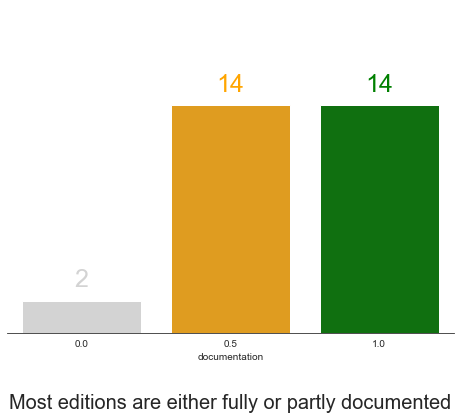

```python
plot_data(data, 'documentation', ['lightgrey', 'orange', 'green'], 'Most editions are either fully or partly documented')
```

The values have been assigned according the following criteria:

- `0`: documentation is non-existent or insufficient;
- `0.5`: documentation is partial and contains superficial information about the project, its contents, and its technical implementation;
- `1`: documentation is complete and contains detailed information about the project, its contents, and its technical implementation.

#### Audience

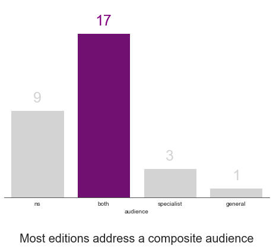

```python
plot_data(data, 'audience', ['lightgray', 'purple', 'lightgray', 'lightgray'], 'Most editions address a composite audience')
```

The values have been assigned according the following criteria:

- `ns`: not specified;
- `specialist`: domain experts, such as researchers, scholars, etc.;
- `general`: laymen;
- `both`: both domain experts and laymen.

#### Representation

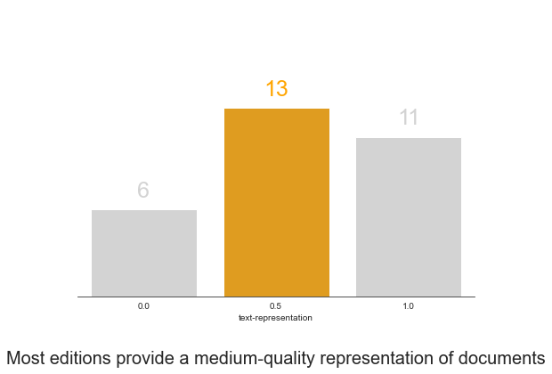

```python
plot_data(data, 'text-representation', ['lightgray', 'orange', 'lightgray'], 'Most editions provide a medium-quality representation of documents')
```

The values have been assigned according the following criteria:

- `0`: documents' representation is low-quality;
- `0.5`: documents' representation is average;
- `1`: documents' representation is high-quality.

#### Data model

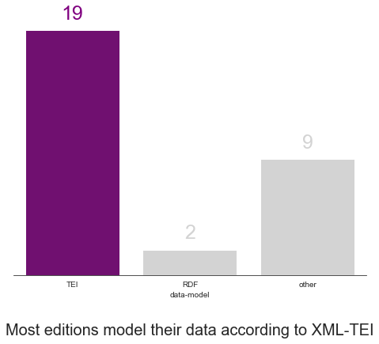

```python
plot_data(data, 'data-model', ['purple', 'lightgray', 'lightgray'], 'Most editions model their data according to XML-TEI')
```

The values have been assigned according the following criteria:

- `TEI`: the digital edition's data model follows the Text Encoding Initiative (TEI) Guidelines;
- `RDF`: the digital edition's data model is based on the Resource Description Framework (RDF);
- `other`: the digital edition's data model is based on a different schema.

### Category: Publication and presentation

#### Browse

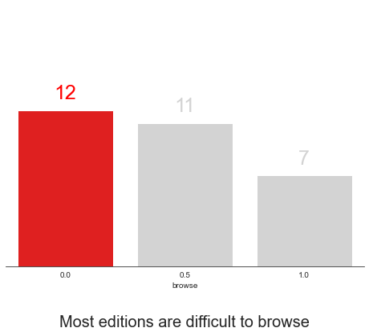

```python
plot_data(data, 'browse', ['red', 'lightgray', 'lightgray'], 'Most editions are difficult to browse')
```

The values have been assigned according the following criteria:

- `0`: browsing is difficult and does not allow rapid access to contents;
- `0.5`: browsing is fairly difficult and allows rapid access to a limited amount of content;
- `1`: browsing is easy and allows rapid access to contents.

#### Search

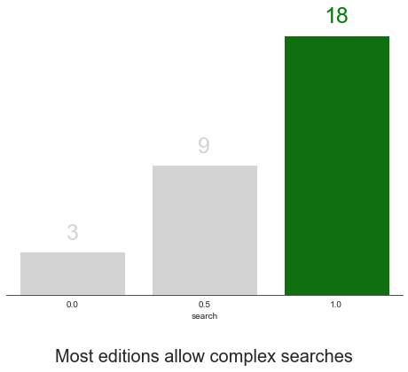

```python
plot_data(data, 'search', ['lightgray', 'lightgray', 'green'], 'Most editions allow complex searches')
```

The values have been assigned according the following criteria:

- `0`: the search system is non-existent, or does not allow query refinement;
- `0.5`: the search system allows limited query refinement;
- `1`: the search system allows complex query refinement.

#### Indexes

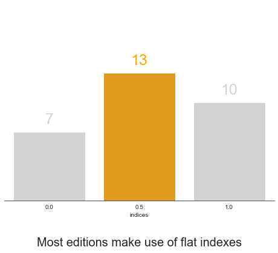

```python
plot_data(data, 'indices', ['lightgray', 'orange', 'lightgray'], 'Most editions make use of flat indexes')
```

The values have been assigned according the following criteria:

- `0`: the digital edition has no indexes;
- `0.5`: the digital edition has a few traditional indexes;
- `1`: the digital edition has an adequate number of indexes that represent an alternative way to navigate the site.

#### Quality of presentation

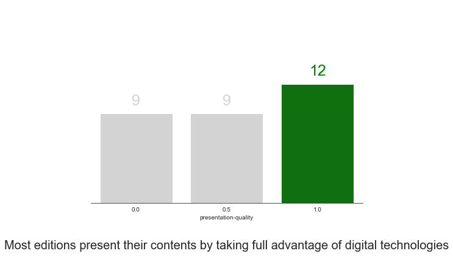

```python
plot_data(data, 'presentation-quality', ['lightgray', 'lightgray', 'green'], 'Most editions present their contents by taking full advantage of digital technologies')
```

The values have been assigned according the following criteria:

- `0`: the digital edition presents its contents as flat text, taking no advantage of digital technologies to visualize additional features;
- `0.5`: the digital edition presents its contents as text that shows a few additional features by taking advantage of digital technologies;
- `1`: the digital edition presents its contents as multidimensional text that shows additional features by taking full advantage of digital technologies.

#### Metadata

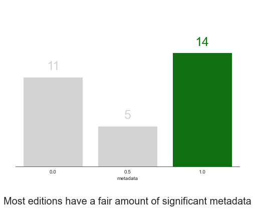

```python
plot_data(data, 'metadata', ['lightgray', 'lightgray', 'green'], 'Most editions have a fair amount of significant metadata')
```

The values have been assigned according the following criteria:

- `0`: the contents of the digital edition are not accompanied by any significant metadata or just by a few of them;
- `0.5`: the contents of the digital edition are accompanied by a limited number of significant metadata;
- `1`: the contents of the digital edition are accompanied by a fair amount of significant metadata.

#### Identification

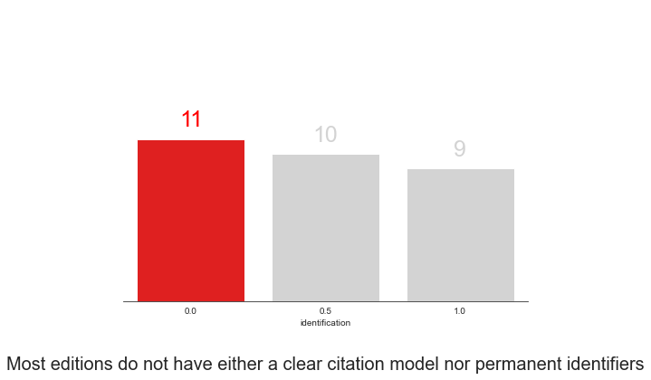

```python
plot_data(data, 'identification', ['red', 'lightgray', 'lightgray'], 'Most editions do not have either a clear citation model nor permanent identifiers')
```

The values have been assigned according the following criteria:

- `0`: the digital edition has no permanent identifiers at any level of granularity and does not provide any clear indication for its citation model;
- `0.5`: the digital edition may have permanent identifiers at the highest levels of granularity and may provide a suggestion for its citation model;
- `1`: the digital edition has permanent identifiers at every level of granularity and provides clear indications for its citation model.

#### Formats

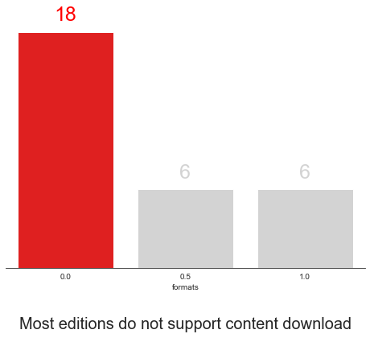

```python
plot_data(data, 'formats', ['red', 'lightgray', 'lightgray'], 'Most editions do not support content download')
```

The values have been assigned according the following criteria:

- `0`: the digital edition do not support content download in any format;
- `0.5`: the digital edition supports at least one format for downloading content, such as PDF or eBook;
- `1`: the digital edition supports multiple formats for downloading content, including structured formats like XML, JSON, ecc.

#### Open Source and Open Access

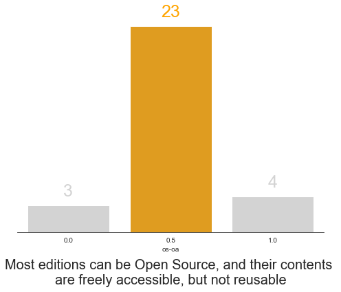

```python
plot_data(data, 'os-oa', ['lightgray', 'orange', 'lightgray'], 'Most editions can be Open Source, and their contents \nare freely accessible, but not reusable')
```

The values have been assigned according the following criteria:

- `0`: the software used to develop the digital edition is not Open Source. The edition's contents cannot be reused by other researchers; in order to access them, the users have to sign in and sometimes pay a subscription fee;
- `0.5`: the software used to develop the digital edition can be Open Source. The edition's contents are freely accessible, but not reusable;
- `1`: the software used to develop the digital edition is Open Source. The edition's contents are freely accessible and reusable.

#### Additional features

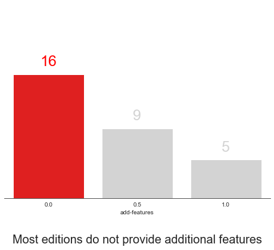

```python
plot_data(data, 'add-features', ['red', 'lightgray', 'lightgray'], 'Most editions do not provide additional features')
```

The values have been assigned according the following criteria:

- `0`: the digital edition does not provide additional features for displaying its contents;
- `0.5`: the digital edition provides basic additional features for displaying its contents;
- `1`: the digital edition provides complex additional features for displaying its contents.

## Conclusions

The final scores are shown below.

[figure not shown]

```python
score_colors = ['lightgreen' if x >= 8 else 'lightgray' for x in data['total'].sort_values(ascending=False).tolist()]
sns.set_style("white")
fig = plt.figure(figsize=(20, 12))
g = sns.barplot(data=data.sort_values(by='total', ascending=False), y='total', x='name', palette=score_colors)
ax=g
for p in ax.patches:
    if p == ax.patches[0] or p == ax.patches[1] or p == ax.patches[2] or p == ax.patches[3] or p == ax.patches[4] or p == ax.patches[5]:
        ax.annotate("%.1f" % p.get_height(), (p.get_x() + p.get_width() / 2, p.get_height()),
                         ha='center', va='center', fontsize=15, color='green', xytext=(0, 10),
                         textcoords='offset points')
    else:
        ax.annotate("%.1f" % p.get_height(), (p.get_x() + p.get_width() / 2, p.get_height()),
                         ha='center', va='center', fontsize=10, color='gray', xytext=(0, 10),
                         textcoords='offset points')
_ = g.set_ylim(0,10)
g.set(yticks=[])
sns.despine(left=True)
ax.set_xlabel('')
ax.set_ylabel('Total score')
plt.title('The editions that have been selected as reference models ', fontsize=20)
plt.xticks(rotation=90)
```

Given these results, the editions that received an optimal score (`>=8`) are:

```python
data_final = data.loc[data['total'] >= 8]
data_final.set_index('name', inplace=True)
data_final
```

| name | url | documentation | audience | text-representation | data-model | browse | search | indices | presentation-quality | metadata | identification | formats | os-oa | add-features | total |
| --- | --- | --- | --- | --- | --- | --- | --- | --- | --- | --- | --- | --- | --- | --- | --- |
| Key Documents of German-Jewish History | https://jewish-history-online.net/ | 1.0 | both | 1.0 | TEI | 1.0 | 0.5 | 1.0 | 1.0 | 1.0 | 0.5 | 1.0 | 0.5 | 1.0 | 9.5 |
| 1914-1918 Online | https://encyclopedia.1914-1918-online.net/home... | 0.0 | both | 0.5 | RDF | 0.5 | 1.0 | 1.0 | 1.0 | 1.0 | 0.5 | 1.0 | 0.5 | 1.0 | 8.0 |
| Epistolario De Gasperi | https://www.epistolariodegasperi.it/ | 0.5 | both | 1.0 | other | 1.0 | 1.0 | 0.5 | 1.0 | 1.0 | 1.0 | 0.5 | 0.5 | 0.0 | 8.0 |
| Lettere di Vespasiano da Bisticci | http://projects.dharc.unibo.it/vespasiano/ | 1.0 | both | 0.5 | RDF | 1.0 | 0.0 | 1.0 | 1.0 | 1.0 | 0.5 | 0.5 | 1.0 | 0.5 | 8.0 |
| Livingstone Online | http://www.livingstoneonline.ucl.ac.uk/ | 1.0 | both | 1.0 | TEI | 0.5 | 1.0 | 0.5 | 1.0 | 1.0 | 0.5 | 1.0 | 1.0 | 0.5 | 9.0 |
| Burckhardt Source | http://burckhardtsource.org/ | 1.0 | both | 1.0 | TEI | 1.0 | 1.0 | 1.0 | 1.0 | 1.0 | 0.0 | 0.0 | 0.5 | 1.0 | 8.5 |

The columns containing textual values (`url`, `audience`, `data-model`), as well as the `total` column, have to be dropped in order to be inserted in a series of radar graphs.

```python
dropped = ['url', 'audience', 'data-model', 'total']
data_final_2 = data_final.drop(dropped, 1)
data_final_2
```

| name | documentation | text-representation | browse | search | indices | presentation-quality | metadata | identification | formats | os-oa | add-features |
| --- | --- | --- | --- | --- | --- | --- | --- | --- | --- | --- | --- |
| Key Documents of German-Jewish History | 1.0 | 1.0 | 1.0 | 0.5 | 1.0 | 1.0 | 1.0 | 0.5 | 1.0 | 0.5 | 1.0 |
| 1914-1918 Online | 0.0 | 0.5 | 0.5 | 1.0 | 1.0 | 1.0 | 1.0 | 0.5 | 1.0 | 0.5 | 1.0 |
| Epistolario De Gasperi | 0.5 | 1.0 | 1.0 | 1.0 | 0.5 | 1.0 | 1.0 | 1.0 | 0.5 | 0.5 | 0.0 |
| Lettere di Vespasiano da Bisticci | 1.0 | 0.5 | 1.0 | 0.0 | 1.0 | 1.0 | 1.0 | 0.5 | 0.5 | 1.0 | 0.5 |
| Livingstone Online | 1.0 | 1.0 | 0.5 | 1.0 | 0.5 | 1.0 | 1.0 | 0.5 | 1.0 | 1.0 | 0.5 |
| Burckhardt Source | 1.0 | 1.0 | 1.0 | 1.0 | 1.0 | 1.0 | 1.0 | 0.0 | 0.0 | 0.5 | 1.0 |

A radar graph has been created for each selected edition, in order to better understand its respective strengths and weaknesses.

### Define the function to visualize the characteristics of the selected models

```python
labels = ['documentation', 'text-representation', 'browse', 'search', 'indices', 'presentation-quality', 'metadata', 'identification', 'formats', 'os-oa', 'add-features']

def generate_radar(title):
    values = data_final_2.loc[title].tolist()
    num_vars = len(labels)

    angles = np.linspace(0, 2 * np.pi, num_vars, endpoint=False).tolist()

    values += values[:1]
    angles += angles[:1]

    fig, ax = plt.subplots(figsize=(6, 6), subplot_kw=dict(polar=True))

    ax.plot(angles, values, color='#1aaf6c', linewidth=1)
    ax.fill(angles, values, color='lightgreen', alpha=0.25)

    ax.set_theta_offset(np.pi / 2)
    ax.set_theta_direction(-1)

    ax.set_thetagrids(np.degrees(angles), labels)

    for label, angle in zip(ax.get_xticklabels(), angles):
      if angle in (0, np.pi):
        label.set_horizontalalignment('center')
      elif 0 < angle < np.pi:
        label.set_horizontalalignment('left')
      else:
        label.set_horizontalalignment('right')

    ax.set_rgrids([0, 0.5, 1])

    ax.set_rlabel_position(180 / num_vars)

    ax.tick_params(colors='#222222')
    ax.tick_params(axis='y', labelsize=8)
    ax.grid(color='#AAAAAA')
    ax.spines['polar'].set_color('#222222')
    ax.set_facecolor('#FAFAFA')

    ax.set_title(title, y=1.08)
```

### Key Documents of German-Jewish History

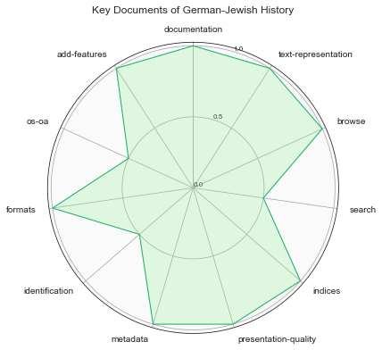

```python
generate_radar('Key Documents of German-Jewish History')
```

[Key Documents of German-Jewish History](https://jewish-history-online.net/) will be used as reference for its **intuitive indices** and **navigation**, **clear documentation**, **metadata**, and overall quality of **textual representation**.

### 1914-1918 Online

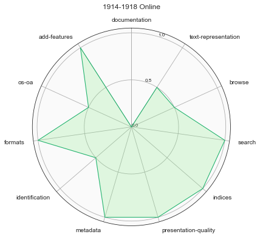

```python
generate_radar('1914-1918 Online')
```

[1914-1918 Online](https://encyclopedia.1914-1918-online.net/home.html) will be used as a reference for how it provides **multiple download formats** and **additional features** such as visualizations, as well as metadata and overall presentation quality.

### Epistolario De Gasperi

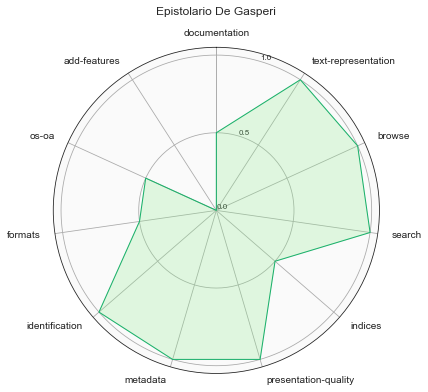

```python
generate_radar('Epistolario De Gasperi')
```

[Epistolario De Gasperi](https://www.epistolariodegasperi.it/) will be used as reference for its **faceted search system** and **minimalistic navigation system**, as well as how its representation of texts, the quality of presentation, and its identification mechanisms.

### Lettere di Vespasiano da Bisticci

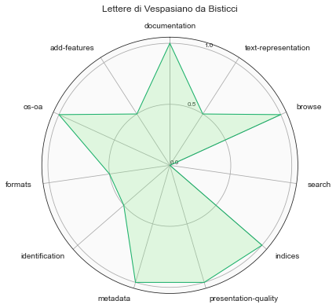

```python
generate_radar('Lettere di Vespasiano da Bisticci')
```

[Lettere di Vespasiano da Bisticci](http://projects.dharc.unibo.it/vespasiano/) will be used as a reference for its **semantic indices** and **in-depth documentation**, as well as its metadata management and quality of presentation.

### Livingstone Online

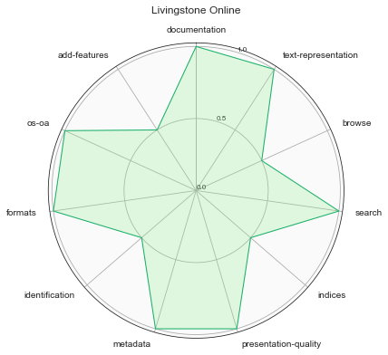

```python
generate_radar('Livingstone Online')
```

[Livingstone Online](https://www.livingstoneonline.org/) will be used as a reference for its **in-depth citable documentation**, **licensing practices**, and **search system**, as well as its variety of download formats, and metadata.

### Burckhardt Source

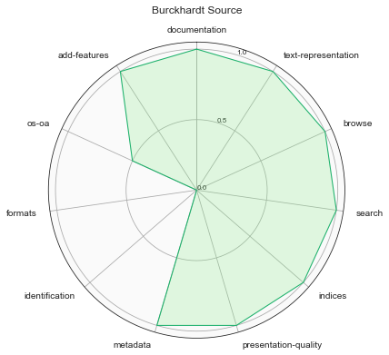

```python
generate_radar('Burckhardt Source')
```

[Burckhardt Source](https://burckhardtsource.org/) will be used as a reference for its **textual representation**, **metadata**, and **faceted search**, as well as its browsing system, indexes, documentation, and additional features.